# PCA of called genotypes: blue wildebeest

**Purpose.** The same PCA as for the human data, on a wild population where the structure is geographic rather than continental. You will also see what linkage disequilibrium does to a PCA, and prune for it properly.

**What you will do**

- run PCAone on the wildebeest genotypes and compare with the admixture proportions
- work out how many PCs carry real structure
- use `PCAone --ld` to measure LD **after** adjusting for population structure, prune, and re-run the PCA
- build an identity-by-state tree from plink distances

**The data.** 73 **blue wildebeest** (*Connochaetes taurinus*) from seven sampling localities in eastern and southern Africa:

| Locality | n |
| --- | --- |
| W-Serengeti (Tanzania) | 28 |
| E-Monduli (Tanzania) | 11 |
| E-Nairobi (Kenya) | 10 |
| E-Amboseli (Kenya) | 9 |
| B-Ethosha (Namibia) | 6 |
| N-Selous (Tanzania) | 6 |
| C-Luangwa (Zambia) | 3 |

**990,980 SNPs** in plink binary format, called from sequencing data. Note how unequal the sample sizes are — 28 from one locality and 3 from another — and keep that in mind when reading the PCA.

**Before this** do MDS and PCA by hand.

## Setup

All the paths used by this exercise are set in the cell below.

```
#############################################################
# ALL PATHS ARE SET HERE
# If the data or the software moves, this is the ONLY cell you
# need to change. No cell below this one uses a full path.
#############################################################

# where the shared data lives
DATA=/course/data/current_data/PCA/animal

# where you will do the exercise
WORK_DIR=$HOME/pca_called_genotypes_animal

mkdir -p $WORK_DIR
echo $WORK_DIR > $HOME/.pca_called_animal_workdir
cd $WORK_DIR

# link the input files into the working folder
cp -sf  $DATA/blue_wildebeest_thin* .
cp -r -sf $DATA/multiRunK7 .

echo --programs that are installed:--
which PCAone
which plink

echo; echo --- files in folder ---
ls
```

```
# the working directory was set in the first cell of the notebook
work_d <- readLines(path.expand("~/.pca_called_animal_workdir"))[1]
setwd(work_d)
getwd()
```

'/davidData/data/course/.nbrender_home/pca_called_genotypes_animal'

# PCA of called genotypes: blue wildebeest

We use the same blue wildebeest data as in the ADMIXTURE analysis, as a plink binary fileset of called genotypes. We run PCAone, compare with the admixture proportions, then prune the data for linkage disequilibrium and see what changes. Finally we build an identity-by-state tree.

If you have not done the MDS and PCA by hand exercise, do that one first.

Let's perform PCA on the whole data (without LD pruning). We will use PCAone:

```
PCAone -h
```

```
PCA All In One (v0.7.2)        https://github.com/Zilong-Li/PCAone
(C) 2021-2024 Zilong Li        GNU General Public License v3

Usage: 1) use PLINK files as input and apply default window-based RSVD method
       $ PCAone -b plink

       2) use CSV file as input and apply the Implicitly Restarted Arnoldi Method
       $ PCAone -c csv.zst -d 0

       3) compute ancestry adjusted LD matrix and R2
       $ PCAone -b plink -k 2 -D -o adj
       $ PCAone -B adj.residuals -f adj.mbim -R --ld-bp 1000


General options:
  -h, --help                     print all options including hidden advanced options
  -m, --memory arg (=0)          RAM usage in GB unit for out-of-core mode. default is in-core mode
  -n, --threads arg (=12)        the number of threads to be used
  -v, --verbose arg (=1)         verbosity level for logs. Options are
                                 0: silent, no messages on screen;
                                 1: concise messages to screen;
                                 2: more verbose information;
                                 3: enable debug information.

PCA algorithms:
  -d, --svd arg (=2)             SVD method to be applied. default 2 is recommended for big data. Options are
                                 0: the Implicitly Restarted Arnoldi Method (IRAM);
                                 1: the Yu's single-pass Randomized SVD with power iterations;
                                 2: the accurate window-based Randomized SVD method (PCAone);
                                 3: the full Singular Value Decomposition.
  -k, --pc arg (=10)             top k principal components (PCs) to be calculated
  -C, --scale arg (=-9)          do normalization or scaling for input file. Options are
                                 -9: standardize genetic data by sqrt(ploidy*f*(1-f));
                                  0: do nothing and proceed to SVD;
                                  1: do direct standardization, as the scale(x, center=TRUE, scale=TRUE) function in R;
                                  2: do first count per median log transformation (CPMED), then standardization;
                                  3: do first log1p transformation, then standardization;
                                  4: do first relative counts, then standardization.
  --maxp arg (=20)               maximum number of power iterations for RSVD algorithm.
  -S, --no-shuffle               do not shuffle columns of data for --svd 2 (if not locally correlated).
```

[output cut: 49 more lines]

```
  --selection arg (=0)           compute selection statistics. Options are
                                 0: disabled;
                                 1: perform selection scan using Galinsky et al method;
                                 2: perform selection scan using PCAdapt method.
  --ld-r2 arg (=0)               R2 cutoff for LD-based pruning (usually 0.2).
  --ld-bp arg (=1000000)         physical distance threshold in bases for LD window.
  --ld-stats arg (=0)            statistics to compute LD R2 for pairwise SNPs. Options are
                                 0: the ancestry adjusted, i.e. correlation between residuals;
                                 1: the standard, i.e. correlation between two alleles.
  --clump arg                    assoc-like file with target variants and pvalues for clumping.
  --clump-names arg (=CHR,BP,P)  column names in assoc-like file for locating chr, pos and pvalue.
  --clump-p1 arg (=0.0001)       significance threshold for index SNPs.
  --clump-p2 arg (=0.01)         secondary significance threshold for clumped SNPs.
  --clump-r2 arg (=0.5)          r2 cutoff for LD-based clumping.
  --clump-bp arg (=250000)       physical distance threshold in bases for clumping.
```

Shows the options. To perform the PCA use the following command

```
PCAone -b blue_wildebeest_thin -o blue_wildebeest_thin
```

```
Machine name: x86_64
Node name: emily
Operating system release: 6.8.0-110-generic
Operating system version: #110~22.04.1-Ubuntu SMP PREEMPT_DYNAMIC Fri Mar 27 12:43:08 UTC
Operating system name: Linux
 PCAone (v0.7.2)    https://github.com/Zilong-Li/PCAone
Options in effect:
PCAone -b blue_wildebeest_thin -o blue_wildebeest_thin
[16/09/2026-20:03:36] program started
[16/09/2026-20:03:36] start parsing PLINK format
[16/09/2026-20:03:36] N (# samples): 73, M (# SNPs): 990980
[16/09/2026-20:03:37] done reading all data
[16/09/2026-20:03:37] initialize window-based RSVD (winSVD) with in-core
[16/09/2026-20:03:37] permuting data matrix by columns in place
[16/09/2026-20:03:43] running of epoch =  1, diff = 0.220309
[16/09/2026-20:03:45] running of epoch =  2, diff = 0.067056
[16/09/2026-20:03:48] running of epoch =  3, diff = 0.060394
[16/09/2026-20:03:50] running of epoch =  4, diff = 0.022161
[16/09/2026-20:03:53] running of epoch =  5, diff = 0.051479
[16/09/2026-20:03:55] running of epoch =  6, diff = 0.000001
[16/09/2026-20:03:55] stops at epoch =  7
[16/09/2026-20:03:55] eigen vectors and values saved
[16/09/2026-20:03:55] PCAone - Randomized SVD done
[16/09/2026-20:03:55] total elapsed reading time:  0.509000 seconds
[16/09/2026-20:03:55] total elapsed wall time: 19.065000 seconds
[16/09/2026-20:03:55] have a nice day. bye!
```

**Question**

- How many SNPs and how many individuals did PCAone use?
- look at the above output. How many SNPs and how many individuals?

The default is to calculate the top 10 PCs. If you want more you can use the option --pc to choose a different number. However, let see what the top PCs capture.

First let look the two first PCs as well as the admixture proportions estimated in the previous admixture exercises

```
#read in code to plot admixture proportions ( plotAdmix function)
source("https://raw.githubusercontent.com/GenisGE/evalAdmix/master/visFuns.R")

options(repr.plot.width=12, repr.plot.height=12)
layout(matrix(c(1,1,2,3),nrow=2,by=T),height=c(2,4),width=2:1)

# Read in inferred admixture proportions
q <- read.table("multiRunK7/blue_wildebeest_noLD.7.Q_4")

#read in the population labels (first column of fam file)
tab <- table(pop <- read.table("blue_wildebeest_thin.fam")[,1])

#make the plot.
plotAdmix(q,pop=pop,rotatelab=15,padj=0.15,cex.lab=1.4,col=c(3,5,8,4,2,6,7))


pca <- read.table("blue_wildebeest_thin.eigvecs")
#layout(matrix(1:2,nrow=1),w=c(4,2))
plot(pca[,1:2],col=as.integer(as.factor(pop))+1,ylab=paste("PC",1),xlab=paste("PC",2),cex.lab=1.5,cex=2,lwd=8)
plot.new()
legend("top",legend=names(tab),bty="n",xpd=T,cex=2,text.col=1:length(tab)+1,text.font=2)
```

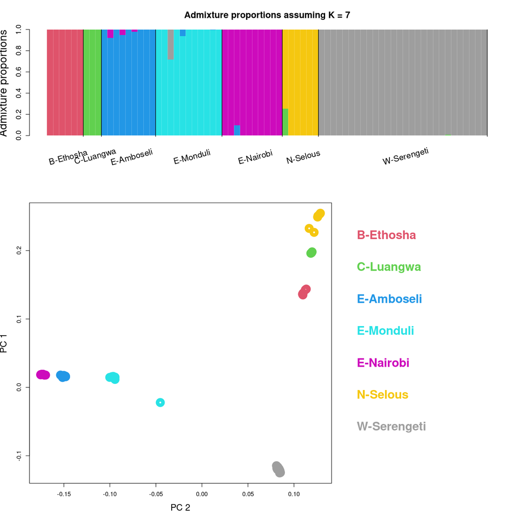

**Questions**

- What information do you get from the PCA that you don't get from the ADMIXTURE results?
- Can you identify the admixed individuals?

### Run the cell below to take the quiz

```
from jupyterquiz import display_quiz

display_quiz("https://raw.githubusercontent.com/popgenDK/courses/main/current_exercises/pca/quiz/pca_animal_structure.json")
```

- What information do you get from the PCA that you don't get from the ADMIXTURE results?
- Can you identify the admixed individuals?

Lets see what the other PCs show.

```
options(repr.plot.width=12, repr.plot.height=16)

par(mfrow=c(3,2))
for(pc in 0:4)
    plot(pca[,pc*2+1:2],col=as.factor(pop),ylab=paste("PC",pc*2+2),xlab=paste("PC",pc*2+1),cex.lab=1.5,cex=2,lwd=8)
```

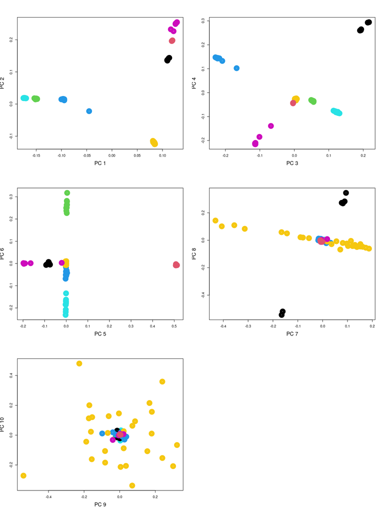

**Questions**

- How many PCs are used to separate the populations?
- What do you think is captured on PC 7 and 8, and on PC 9 and 10?
- How many PCs are used to separate the populations?
- What do you think is captured on PC 7 and 8?
- What do you think is captured on PC 9 and 10?

## Bonus exercise if there is time

Lets try to run the PCA after pruning LD (linkage disequillibrium) from the data. The noLD data was created in the admixture exercise. Run first the pruning with PCA and then run PCA on the pruned data

```
PCAone -b blue_wildebeest_thin -k 6 --ld -o pcaone
```

```
Machine name: x86_64
Node name: emily
Operating system release: 6.8.0-110-generic
Operating system version: #110~22.04.1-Ubuntu SMP PREEMPT_DYNAMIC Fri Mar 27 12:43:08 UTC
Operating system name: Linux
 PCAone (v0.7.2)    https://github.com/Zilong-Li/PCAone
Options in effect:
PCAone -b blue_wildebeest_thin -k 6 --ld -o pcaone
[16/09/2026-20:03:58] program started
[16/09/2026-20:03:58] start parsing PLINK format
[16/09/2026-20:03:58] N (# samples): 73, M (# SNPs): 990980
[16/09/2026-20:03:58] done reading all data
You are recommended to use --svd 1 for outputting the LD residual matrix
[16/09/2026-20:03:58] initialize window-based RSVD (winSVD) with in-core
[16/09/2026-20:03:58] permuting data matrix by columns in place
[16/09/2026-20:04:02] running of epoch =  1, diff = 0.018019
[16/09/2026-20:04:04] running of epoch =  2, diff = 0.000368
[16/09/2026-20:04:06] running of epoch =  3, diff = 0.000325
[16/09/2026-20:04:07] running of epoch =  4, diff = 0.000090
PCAone winSVD converged but continues running to get S and V.
[16/09/2026-20:04:09] running of epoch =  5, diff = 0.000113
[16/09/2026-20:04:11] running of epoch =  6, diff = 0.000000
[16/09/2026-20:04:11] stops at epoch =  7
[16/09/2026-20:04:11] ld-stats=0: calculate the ancestry adjusted LD matrix!
[16/09/2026-20:04:15] save matched sites in .mbim file and permutation mode is  1
[16/09/2026-20:04:15] the LD matrix and SNPs info are saved
[16/09/2026-20:04:15] eigen vectors and values saved
[16/09/2026-20:04:15] PCAone - Randomized SVD done
[16/09/2026-20:04:15] total elapsed reading time:  0.509000 seconds
[16/09/2026-20:04:15] total elapsed wall time: 17.397000 seconds
[16/09/2026-20:04:15] have a nice day. bye!
```

**Question**

- `--ld` makes PCAone compute LD **after** adjusting for population structure. Why would unadjusted LD be misleading in a structured sample?

```
#see created files
ls pcaone*
```

```
pcaone.eigvals	pcaone.eigvecs2  pcaone.mbim	   pcaone.sigvals
pcaone.eigvecs	pcaone.log	 pcaone.residuals
```

```
PCAone -B pcaone.residuals \
         --match-bim pcaone.mbim \
         --ld-r2 0.1 \
         --ld-bp 1000000 \
         -o pcaone
```

```
Machine name: x86_64
Node name: emily
Operating system release: 6.8.0-110-generic
Operating system version: #110~22.04.1-Ubuntu SMP PREEMPT_DYNAMIC Fri Mar 27 12:43:08 UTC
Operating system name: Linux
 PCAone (v0.7.2)    https://github.com/Zilong-Li/PCAone
Options in effect:
PCAone -B pcaone.residuals --match-bim pcaone.mbim --ld-r2 0.1 --ld-bp 1000000 -o pcaone
[16/09/2026-20:04:16] program started
[16/09/2026-20:04:16] start parsing binary format
[16/09/2026-20:04:16] shape of input matrix (features x samples) is 990980 x 73
[16/09/2026-20:04:16] run LD stuff
[16/09/2026-20:04:16] read allele frequency from .mbim file: pcaone.mbim
[16/09/2026-20:04:17] done reading all data
[16/09/2026-20:04:17] LD pruning, choose sites to be kept randomly or with high MAF? 1(random) : 0(high MAF). =>  0
[16/09/2026-20:04:18] 37567 sites will be kept
[16/09/2026-20:04:20] total elapsed wall time: 4.472000 seconds
[16/09/2026-20:04:20] have a nice day. bye!
```

**Questions**

- `--ld-r2 0.1` and `--ld-bp 1000000` set the pruning. What do the two numbers mean?
- Why prune on LD at all before a PCA?

The LD measure has been adjusted for population structure using the PCs.

- Why does the LD need to be adjusted for population structure?
- Why do we use a sliding window?

Lets make a new plink file containing only the markers in low LD

```
echo --number of variants to be kept --
wc -l pcaone.ld.prune.in

echo -e "\n --Extract variants using plink --"
plink --bfile blue_wildebeest_thin \
    --extract pcaone.ld.prune.in  \
    --make-bed  \
    --out blue_wildebeest_noLD  \
    --chr-set 29
```

```
--number of variants to be kept --
37567 pcaone.ld.prune.in

 --Extract variants using plink --
PLINK v1.90b6 64-bit (26 May 2018)             www.cog-genomics.org/plink/1.9/
(C) 2005-2018 Shaun Purcell, Christopher Chang   GNU General Public License v3
Logging to blue_wildebeest_noLD.log.
Options in effect:
  --bfile blue_wildebeest_thin
  --chr-set 29
  --extract pcaone.ld.prune.in
  --make-bed
  --out blue_wildebeest_noLD

386830 MB RAM detected; reserving 193415 MB for main workspace.
990980 variants loaded from .bim file.
73 samples (0 males, 0 females, 73 ambiguous) loaded from .fam.
Ambiguous sex IDs written to blue_wildebeest_noLD.nosex .
--extract: 37567 variants remaining.
Using 1 thread (no multithreaded calculations invoked).
Before main variant filters, 73 founders and 0 nonfounders present.
Calculating allele frequencies... 0%1%2%3%4%5%6%7%8%9%10%11%12%13%14%15%16%17%18%19%20%21%22%23%24%25%26%27%28%29%30%31%32%33%34%35%36%37%38%39%40%41%42%43%44%45%46%47%48%49%50%51%52%53%54%55%56%57%58%59%60%61%62%63%64%65%66%67%68%69%70%71%72%73%74%75%76%77%78%79%80%81%82%83%84%85%86%87%88%89%90%91%…
Total genotyping rate is 0.998514.
37567 variants and 73 samples pass filters and QC.
Note: No phenotypes present.
--make-bed to blue_wildebeest_noLD.bed + blue_wildebeest_noLD.bim +
blue_wildebeest_noLD.fam ... 0%1%2%3%4%5%6%7%8%9%10%11%12%13%14%15%16%17%18%19%20%21%22%23%24%25%26%27%28%29%30%31%32%33%34%35%36%37%38%39%40%41%42%43%44%45%46%47%48%49%50%51%52%53%54%55%56%57%58%59%60%61%62%63%64%65%66%67%68%69%70%71%72%73%74%75%76%77%78%79%80%81%82%83%84%85%86%87%88%89%90%91%92%93…
```

**Question**

- How many variants were kept out of the original set?

We can now perform the PCA again on the pruned data

```
PCAone  -b blue_wildebeest_noLD -o blue_wildebeest_noLD
```

```
Machine name: x86_64
Node name: emily
Operating system release: 6.8.0-110-generic
Operating system version: #110~22.04.1-Ubuntu SMP PREEMPT_DYNAMIC Fri Mar 27 12:43:08 UTC
Operating system name: Linux
 PCAone (v0.7.2)    https://github.com/Zilong-Li/PCAone
Options in effect:
PCAone -b blue_wildebeest_noLD -o blue_wildebeest_noLD
[16/09/2026-20:04:21] program started
[16/09/2026-20:04:21] start parsing PLINK format
[16/09/2026-20:04:21] N (# samples): 73, M (# SNPs): 37567
[16/09/2026-20:04:21] done reading all data
[16/09/2026-20:04:21] initialize window-based RSVD (winSVD) with in-core
[16/09/2026-20:04:21] permuting data matrix by columns in place
[16/09/2026-20:04:21] running of epoch =  1, diff = 0.159567
[16/09/2026-20:04:21] running of epoch =  2, diff = 0.075697
[16/09/2026-20:04:21] running of epoch =  3, diff = 0.092925
[16/09/2026-20:04:21] running of epoch =  4, diff = 0.106817
[16/09/2026-20:04:22] running of epoch =  5, diff = 0.068094
[16/09/2026-20:04:22] running of epoch =  6, diff = 0.000015
[16/09/2026-20:04:22] stops at epoch =  7
[16/09/2026-20:04:22] eigen vectors and values saved
[16/09/2026-20:04:22] PCAone - Randomized SVD done
[16/09/2026-20:04:22] total elapsed reading time:  0.025000 seconds
[16/09/2026-20:04:22] total elapsed wall time: 0.509000 seconds
[16/09/2026-20:04:22] have a nice day. bye!
```

**Question**

- Compare the singular values before and after pruning. Which data set captures more of the population structure in its top PCs?

We can start by comparing the singular values. These are proportional to the variance explained so that higher values means that the corresponding PC captures more information about the data.

```
options(repr.plot.width=12, repr.plot.height=8)

singularValues <- scan("blue_wildebeest_thin.eigvals")
singularValuesNoLD <- scan("blue_wildebeest_noLD.eigvals")

varianceExplained <- function(x)
    x^2/sum(x^2)

varExp <- varianceExplained(rbind(singularValues,singularValuesNoLD))


barplot(varExp*100,beside=T,col=2:3,legend=c("With LD","Without LD"),
       ylab="%variance explained",xlab="PC 1:10")
```

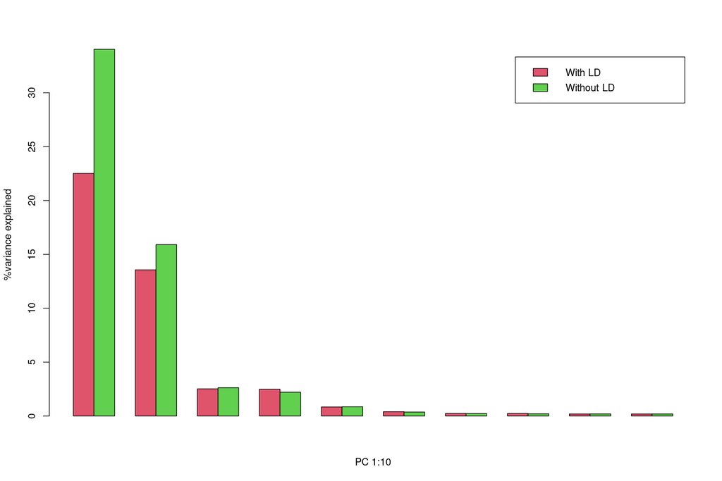

```
Read 10 items
Read 10 items
```

- which data set captures the most information about the population structure from the first top PCs?

Lets plot the PCs from the two data sets

```
options(repr.plot.width=12, repr.plot.height=32)

tab <- table(pop <- read.table("blue_wildebeest_noLD.fam")[,1])


pcaNoLD <- read.table("blue_wildebeest_noLD.eigvecs")


par(mfrow=c(5,2))
for(pc in 0:4){

    plot(pca[,pc*2+1:2],col=as.factor(pop),ylab=paste("PC",pc*2+2),xlab=paste("PC",pc*2+1),cex.lab=1.5,cex=2,lwd=8,main="with LD")
    plot(pcaNoLD[,pc*2+1:2],col=as.factor(pop),ylab=paste("PC",pc*2+2),xlab=paste("PC",pc*2+1),cex.lab=1.5,cex=2,lwd=8,main="No LD")


    }
```

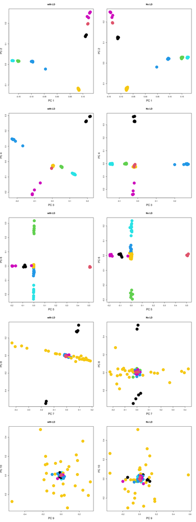

- Which of the PCs from previous analysis capture LD and not population structure?
- Do you think it is better to perform PCA with out without LD?

**Questions**

- Which of the PCs from the unpruned analysis capture LD rather than population structure?
- Do you think it is better to prune or not, and what do you lose by pruning?

### Run the cell below to take the quiz

```
from jupyterquiz import display_quiz

display_quiz("https://raw.githubusercontent.com/popgenDK/courses/main/current_exercises/pca/quiz/pca_ld_pruning.json")
```

## Identity by state tree

As a last minute addition we can also make a neighbour joining tree by first computing identity-by-state distances between individuals which a just the proportion of sites between two individuals where they are different. We can then load these distances into R and produce a NJ tree with the package APE.

```
# get IBS distances with plink
plink --allow-extra-chr \
    --bfile blue_wildebeest_thin \
    --distance square 1-ibs \
    --chr-set 29 \
    --out plink
```

```
PLINK v1.90b6 64-bit (26 May 2018)             www.cog-genomics.org/plink/1.9/
(C) 2005-2018 Shaun Purcell, Christopher Chang   GNU General Public License v3
Logging to plink.log.
Options in effect:
  --allow-extra-chr
  --bfile blue_wildebeest_thin
  --chr-set 29
  --distance square 1-ibs
  --out plink

386830 MB RAM detected; reserving 193415 MB for main workspace.
990980 variants loaded from .bim file.
73 samples (0 males, 0 females, 73 ambiguous) loaded from .fam.
Ambiguous sex IDs written to plink.nosex .
Using up to 87 threads (change this with --threads).
Before main variant filters, 73 founders and 0 nonfounders present.
Calculating allele frequencies... 0%1%2%3%4%5%6%7%8%9%10%11%12%13%14%15%16%17%18%19%20%21%22%23%24%25%26%27%28%29%30%31%32%33%34%35%36%37%38%39%40%41%42%43%44%45%46%47%48%49%50%51%52%53%54%55%56%57%58%59%60%61%62%63%64%65%66%67%68%69%70%71%72%73%74%75%76%77%78%79%80%81%82%83%84%85%86%87%88%89%90%91%…
Total genotyping rate is 0.999215.
990980 variants and 73 samples pass filters and QC.
Note: No phenotypes present.
Distance matrix calculation complete.
IDs written to plink.mdist.id .
Distances (proportions) written to plink.mdist .
```

**Question**

- The IBS tree is built from pairwise distances rather than from PCs. Does it group the individuals the same way?

```
library(ape)

# read in distances
m <- as.matrix(read.table("plink.mdist", header = F))

# read id of individuals
id <- read.table("plink.mdist.id")
rownames(m) <- id$V2
colnames(m) <- id$V2

pops <- c(4,6,8,2,5,7,3)
names(pops) <- unique(id$V1)

plot(nj(m), tip.color = pops[id$V1], type = "unrooted", show.tip.label = TRUE)
add.scale.bar()
legend("topright",
       legend = names(pops),
       fill = pops,
          ncol=4)
```

[figure not shown]

- Can you find the admixed individual?
- Try removing the " type = 'unrooted'," argument from the plotting command above and see what happens to the tree

**Questions**